# Risk Factor Analysis

## Outcome Variable

**Outcome Variable:** ever_stunted

## Predictor Variables

**Intervention Variable:** tr

**Adjustment Set:**

unadjusted

## Stratifying Variables

The analysis was stratified on these variable(s):

- trth2o
- agecat
- studyid
- country

## Data Summary

| trth2o | agecat | studyid | country | tr | ever_stunted | n_cell | n |
| --- | --- | --- | --- | --- | --- | --- | --- |
| 0 | 0-6 months | ki1017093b-PROVIDE | BANGLADESH | Control | 0 | 138 | 626 |
| 0 | 0-6 months | ki1017093b-PROVIDE | BANGLADESH | Control | 1 | 24 | 626 |
| 0 | 0-6 months | ki1017093b-PROVIDE | BANGLADESH | Other | 0 | 399 | 626 |
| 0 | 0-6 months | ki1017093b-PROVIDE | BANGLADESH | Other | 1 | 65 | 626 |
| 1 | 0-6 months | ki1017093b-PROVIDE | BANGLADESH | Control | 0 | 4 | 14 |
| 1 | 0-6 months | ki1017093b-PROVIDE | BANGLADESH | Other | 0 | 10 | 14 |
| 0 | 6-24 months | ki1017093b-PROVIDE | BANGLADESH | Control | 0 | 100 | 484 |
| 0 | 6-24 months | ki1017093b-PROVIDE | BANGLADESH | Control | 1 | 23 | 484 |
| 0 | 6-24 months | ki1017093b-PROVIDE | BANGLADESH | Other | 0 | 270 | 484 |
| 0 | 6-24 months | ki1017093b-PROVIDE | BANGLADESH | Other | 1 | 91 | 484 |
| 1 | 6-24 months | ki1017093b-PROVIDE | BANGLADESH | Control | 0 | 1 | 13 |
| 1 | 6-24 months | ki1017093b-PROVIDE | BANGLADESH | Control | 1 | 2 | 13 |
| 1 | 6-24 months | ki1017093b-PROVIDE | BANGLADESH | Other | 0 | 7 | 13 |
| 1 | 6-24 months | ki1017093b-PROVIDE | BANGLADESH | Other | 1 | 3 | 13 |
| 0 | 0-24 months | ki1017093b-PROVIDE | BANGLADESH | Control | 0 | 100 | 627 |
| 0 | 0-24 months | ki1017093b-PROVIDE | BANGLADESH | Control | 1 | 62 | 627 |
| 0 | 0-24 months | ki1017093b-PROVIDE | BANGLADESH | Other | 0 | 271 | 627 |
| 0 | 0-24 months | ki1017093b-PROVIDE | BANGLADESH | Other | 1 | 194 | 627 |
| 1 | 0-24 months | ki1017093b-PROVIDE | BANGLADESH | Control | 0 | 1 | 14 |
| 1 | 0-24 months | ki1017093b-PROVIDE | BANGLADESH | Control | 1 | 3 | 14 |
| 1 | 0-24 months | ki1017093b-PROVIDE | BANGLADESH | Other | 0 | 7 | 14 |
| 1 | 0-24 months | ki1017093b-PROVIDE | BANGLADESH | Other | 1 | 3 | 14 |

The following strata were considered:

- trth2o: 0, agecat: 0-24 months, studyid: ki1017093b-PROVIDE, country: BANGLADESH
- trth2o: 0, agecat: 0-6 months, studyid: ki1017093b-PROVIDE, country: BANGLADESH
- trth2o: 0, agecat: 6-24 months, studyid: ki1017093b-PROVIDE, country: BANGLADESH
- trth2o: 1, agecat: 0-24 months, studyid: ki1017093b-PROVIDE, country: BANGLADESH
- trth2o: 1, agecat: 0-6 months, studyid: ki1017093b-PROVIDE, country: BANGLADESH
- trth2o: 1, agecat: 6-24 months, studyid: ki1017093b-PROVIDE, country: BANGLADESH

### Dropped Strata

Some strata were dropped due to rare outcomes:

- trth2o: 1, agecat: 0-6 months, studyid: ki1017093b-PROVIDE, country: BANGLADESH
- trth2o: 1, agecat: 6-24 months, studyid: ki1017093b-PROVIDE, country: BANGLADESH
- trth2o: 1, agecat: 0-24 months, studyid: ki1017093b-PROVIDE, country: BANGLADESH

## Methods Detail

We’re interested in the causal parameters $E[Y_a]$ for all values of $a \in \mathcal{A}$. These parameters represent the mean outcome if, possibly contrary to fact, we intervened to set all units to have $A=a$. Under the randomization and positivity assumptions, these are identified by the statistical parameters $\psi_a=E_W[E_{Y|A,W}(Y|A=a,W)]$. In addition, we’re interested in the mean of $Y$, $E[Y]$ under no intervention (the observed mean). We will estimate these parameters by using SuperLearner to fit the relevant likelihood factors – $E_{Y|A,W}(Y|A=a,W)$ and $p(A=a|W)$, and then updating our likelihood fit using a joint TMLE.

For unadjusted analyses ($W=\{\}$), initial likelihoods were estimated using Lrnr_glm to estimate the simple $E(Y|A)$ and Lrnr_mean to estimate $p(A)$. For adjusted analyses, a small library containing Lrnr_glmnet, Lrnr_xgboost, and Lrnr_mean was used.

Having estimated these parameters, we will then use the delta method to estimate relative risks and attributable risks relative to a prespecified baseline level of $A$.

# Results Detail

## Results Plots

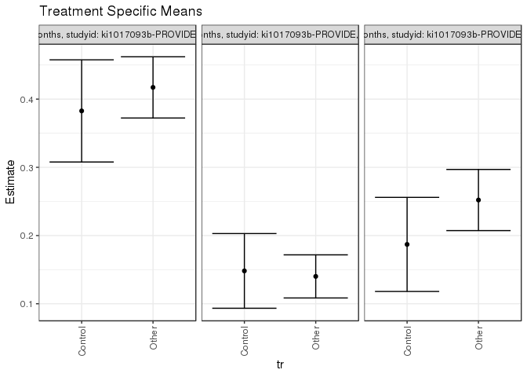

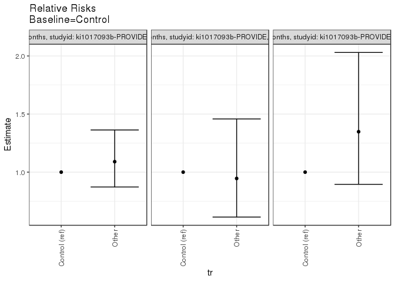

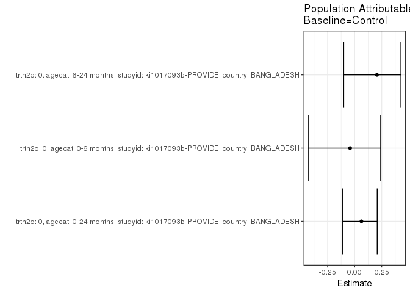

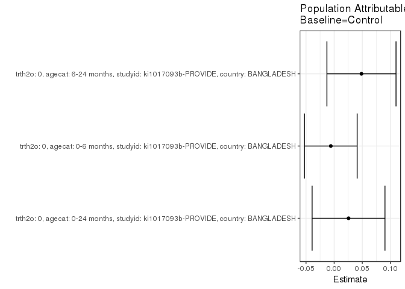

## Results Table

### Parameter: TSM

| trth2o | agecat | studyid | country | intervention_level | baseline_level | estimate | ci_lower | ci_upper |
| --- | --- | --- | --- | --- | --- | --- | --- | --- |
| 0 | 0-24 months | ki1017093b-PROVIDE | BANGLADESH | Control | NA | 0.3827160 | 0.3078098 | 0.4576223 |
| 0 | 0-24 months | ki1017093b-PROVIDE | BANGLADESH | Other | NA | 0.4172043 | 0.3723503 | 0.4620583 |
| 0 | 0-6 months | ki1017093b-PROVIDE | BANGLADESH | Control | NA | 0.1481481 | 0.0934002 | 0.2028961 |
| 0 | 0-6 months | ki1017093b-PROVIDE | BANGLADESH | Other | NA | 0.1400862 | 0.1084808 | 0.1716916 |
| 0 | 6-24 months | ki1017093b-PROVIDE | BANGLADESH | Control | NA | 0.1869919 | 0.1180150 | 0.2559687 |
| 0 | 6-24 months | ki1017093b-PROVIDE | BANGLADESH | Other | NA | 0.2520776 | 0.2072403 | 0.2969148 |

### Parameter: E(Y)

| trth2o | agecat | studyid | country | intervention_level | baseline_level | estimate | ci_lower | ci_upper |
| --- | --- | --- | --- | --- | --- | --- | --- | --- |
| 0 | 0-24 months | ki1017093b-PROVIDE | BANGLADESH | NA | NA | 0.4082935 | 0.3697900 | 0.4467970 |
| 0 | 0-6 months | ki1017093b-PROVIDE | BANGLADESH | NA | NA | 0.1421725 | 0.1147936 | 0.1695514 |
| 0 | 6-24 months | ki1017093b-PROVIDE | BANGLADESH | NA | NA | 0.2355372 | 0.1976945 | 0.2733799 |

### Parameter: RR

| trth2o | agecat | studyid | country | intervention_level | baseline_level | estimate | ci_lower | ci_upper |
| --- | --- | --- | --- | --- | --- | --- | --- | --- |
| 0 | 0-24 months | ki1017093b-PROVIDE | BANGLADESH | Control | Control | 1.0000000 | 1.0000000 | 1.000000 |
| 0 | 0-24 months | ki1017093b-PROVIDE | BANGLADESH | Other | Control | 1.0901145 | 0.8719491 | 1.362866 |
| 0 | 0-6 months | ki1017093b-PROVIDE | BANGLADESH | Control | Control | 1.0000000 | 1.0000000 | 1.000000 |
| 0 | 0-6 months | ki1017093b-PROVIDE | BANGLADESH | Other | Control | 0.9455819 | 0.6132820 | 1.457935 |
| 0 | 6-24 months | ki1017093b-PROVIDE | BANGLADESH | Control | Control | 1.0000000 | 1.0000000 | 1.000000 |
| 0 | 6-24 months | ki1017093b-PROVIDE | BANGLADESH | Other | Control | 1.3480670 | 0.8950733 | 2.030319 |

### Parameter: PAR

| trth2o | agecat | studyid | country | intervention_level | baseline_level | estimate | ci_lower | ci_upper |
| --- | --- | --- | --- | --- | --- | --- | --- | --- |
| 0 | 0-24 months | ki1017093b-PROVIDE | BANGLADESH | Control | NA | 0.0255774 | -0.0391839 | 0.0903387 |
| 0 | 0-6 months | ki1017093b-PROVIDE | BANGLADESH | Control | NA | -0.0059756 | -0.0528329 | 0.0408817 |
| 0 | 6-24 months | ki1017093b-PROVIDE | BANGLADESH | Control | NA | 0.0485453 | -0.0128685 | 0.1099591 |

### Parameter: PAF

| trth2o | agecat | studyid | country | intervention_level | baseline_level | estimate | ci_lower | ci_upper |
| --- | --- | --- | --- | --- | --- | --- | --- | --- |
| 0 | 0-24 months | ki1017093b-PROVIDE | BANGLADESH | Control | NA | 0.0626447 | -0.1102183 | 0.2085926 |
| 0 | 0-6 months | ki1017093b-PROVIDE | BANGLADESH | Control | NA | -0.0420308 | -0.4296014 | 0.2404679 |
| 0 | 6-24 months | ki1017093b-PROVIDE | BANGLADESH | Control | NA | 0.2061047 | -0.1010574 | 0.4275777 |